# Exploración y Procesamiento de los Datos

Importo las librerías **Pandas** y **Numpy** con los alias **`pd`** y **`np`** respectivamente

```python
import pandas as pd
import numpy as np
```

## Importación del dataset para crear el dataframe

Importo el dataset que es un archivo de excel usando la función **`read_excel()`** de Pandas. Y el resultado lo almaceno en la variable **`df`**.

```python
df = pd.read_excel('Salary.xlsx')
df
```

|  | YearsExperience,Salary |
| --- | --- |
| 0 | 1.1,39343 |
| 1 | 1.3,46205 |
| 2 | 1.5,37731 |
| 3 | 2.43525 |
| 4 | 2.2,39891 |
| 5 | 2.9,56642 |
| 6 | 3.6015 |
| 7 | 3.2,54445 |
| 8 | 3.2,64445 |
| 9 | 3.7,57189 |
| 10 | 3.9,63218 |
| 11 | 4.55794 |
| 12 | 4.56957 |
| 13 | 4.1,57081 |
| 14 | 4.5,61111 |
| 15 | 4.9,67938 |
| 16 | 5.1,66029 |
| 17 | 5.3,83088 |
| 18 | 5.9,81363 |
| 19 | 6.9394 |
| 20 | 6.8,91738 |
| 21 | 7.1,98273 |
| 22 | 7.9,101302 |
| 23 | 8.2,113812 |
| 24 | 8.7,109431 |
| 25 | 9.105582 |
| 26 | 9.5,116969 |
| 27 | 9.6,112635 |
| 28 | 10.3,122391 |
| 29 | 10.5,121872 |
| 30 | 11.2,127345 |
| 31 | 11.5,126756 |
| 32 | 12.3,128765 |
| 33 | 12.9,135675 |
| 34 | 13.5,139465 |

## Exploración de los datos del dataframe

### Tipos de datos originales:

Se le aplica al dataframe el atributo **`dtypes`** para ver el tipo de dato de la columna:

```python
df.dtypes
```

```
YearsExperience,Salary    object
dtype: object
```

Como el tipo de dato de la columna en Pandas es object puede ser que tenga en la misma columna distintos tipos de datos. Para ver qué tipo de datos hay accedo a la columna y le aplico el método **`apply()`** con el atributo `type`.

```python
df['YearsExperience,Salary'].apply(type)
```

```
0       <class 'str'>
1       <class 'str'>
2       <class 'str'>
3     <class 'float'>
4       <class 'str'>
5       <class 'str'>
6     <class 'float'>
7       <class 'str'>
8       <class 'str'>
9       <class 'str'>
10      <class 'str'>
11    <class 'float'>
12    <class 'float'>
13      <class 'str'>
14      <class 'str'>
```

[output cut: 21 more lines]

Así se puede ver que en la columna hay valores de tipo str y valores de tipo float.

En el dataframe se puede ver que los valores de tipo string lo son porque tienen una coma (,) que separa los años de experiencia del salario. Para separar estos dos valores en dos columnas distintas aplico el método **`str.split()`** con el parametro `,` que indica que la división se hace en la coma, y el parametro `expand=True` para indicar que caada resultado de la escisión del string va en dos columnas separadas. El dataframe resultante se almacena en una nueva variable.

```python
df1 = df['YearsExperience,Salary'].str.split(pat=',', expand=True)
df1
```

|  | 0 | 1 |
| --- | --- | --- |
| 0 | 1.1 | 39343 |
| 1 | 1.3 | 46205 |
| 2 | 1.5 | 37731 |
| 3 | NaN | NaN |
| 4 | 2.2 | 39891 |
| 5 | 2.9 | 56642 |
| 6 | NaN | NaN |
| 7 | 3.2 | 54445 |
| 8 | 3.2 | 64445 |
| 9 | 3.7 | 57189 |
| 10 | 3.9 | 63218 |
| 11 | NaN | NaN |
| 12 | NaN | NaN |
| 13 | 4.1 | 57081 |
| 14 | 4.5 | 61111 |
| 15 | 4.9 | 67938 |
| 16 | 5.1 | 66029 |
| 17 | 5.3 | 83088 |
| 18 | 5.9 | 81363 |
| 19 | NaN | NaN |
| 20 | 6.8 | 91738 |
| 21 | 7.1 | 98273 |
| 22 | 7.9 | 101302 |
| 23 | 8.2 | 113812 |
| 24 | 8.7 | 109431 |
| 25 | NaN | NaN |
| 26 | 9.5 | 116969 |
| 27 | 9.6 | 112635 |
| 28 | 10.3 | 122391 |
| 29 | 10.5 | 121872 |
| 30 | 11.2 | 127345 |
| 31 | 11.5 | 126756 |
| 32 | 12.3 | 128765 |
| 33 | 12.9 | 135675 |
| 34 | 13.5 | 139465 |

Como se puede ver el dataframe resultante contiene valores NaN que corresponden a los valores de tipo float del dataframe original, y se mantienen como valores NaN para el tratamiendo del dataframe.

### Cambio de nombre de las columnas:

A continuación, utilizamos el método **`rename()`** para renombrar las columnas, para ellos se pasa como parametro un diccionario donde la clave es el nombre original de la columna y el valor es el nuevo nombre de la columna. Y se pasa por parametro el `inplace=True` para que el cambio de nombre de columna se realice en el objeto asignado, es decir, en el mismo dataframe.

```python
df1.rename(columns = {0:'Años de experiencia', 1:'Sueldo'}, inplace=True)
df1
```

|  | Años de experiencia | Sueldo |
| --- | --- | --- |
| 0 | 1.1 | 39343 |
| 1 | 1.3 | 46205 |
| 2 | 1.5 | 37731 |
| 3 | NaN | NaN |
| 4 | 2.2 | 39891 |
| 5 | 2.9 | 56642 |
| 6 | NaN | NaN |
| 7 | 3.2 | 54445 |
| 8 | 3.2 | 64445 |
| 9 | 3.7 | 57189 |
| 10 | 3.9 | 63218 |
| 11 | NaN | NaN |
| 12 | NaN | NaN |
| 13 | 4.1 | 57081 |
| 14 | 4.5 | 61111 |
| 15 | 4.9 | 67938 |
| 16 | 5.1 | 66029 |
| 17 | 5.3 | 83088 |
| 18 | 5.9 | 81363 |
| 19 | NaN | NaN |
| 20 | 6.8 | 91738 |
| 21 | 7.1 | 98273 |
| 22 | 7.9 | 101302 |
| 23 | 8.2 | 113812 |
| 24 | 8.7 | 109431 |
| 25 | NaN | NaN |
| 26 | 9.5 | 116969 |
| 27 | 9.6 | 112635 |
| 28 | 10.3 | 122391 |
| 29 | 10.5 | 121872 |
| 30 | 11.2 | 127345 |
| 31 | 11.5 | 126756 |
| 32 | 12.3 | 128765 |
| 33 | 12.9 | 135675 |
| 34 | 13.5 | 139465 |

### Cambio de tipo de dato:

```python
df1['Años de experiencia'].apply(type)
```

```
0       <class 'str'>
1       <class 'str'>
2       <class 'str'>
3     <class 'float'>
4       <class 'str'>
5       <class 'str'>
6     <class 'float'>
7       <class 'str'>
8       <class 'str'>
9       <class 'str'>
10      <class 'str'>
11    <class 'float'>
12    <class 'float'>
13      <class 'str'>
14      <class 'str'>
```

[output cut: 21 more lines]

Como se puede observar aunque se haya separado los valores y colocado cada uno en su columna correspondiente, el tipo de dato de la mayoría de los valores sigue siento str, y como lo más conveniente para trabajar con datos numéricos es que sean de tipo int o float, se utiliza la función **`astype()`** para cambiar el tipo de dato de todos los valores de cada una de las dos columnas.

```python
df1['Sueldo'] = df1['Sueldo'].astype(float) #Cambio el tipo de dato de la columna Sueldo
```

```python
df1['Años de experiencia'] = df1['Años de experiencia'].astype(float) #cambio el tipo de dato de la columna Años de experiencia
```

Verificamos que los tipo de dato sean float:

```python
df1['Sueldo'].apply(type).head()
```

```
0    <class 'float'>
1    <class 'float'>
2    <class 'float'>
3    <class 'float'>
4    <class 'float'>
Name: Sueldo, dtype: object
```

```python
df1['Años de experiencia'].apply(type).head()
```

```
0    <class 'float'>
1    <class 'float'>
2    <class 'float'>
3    <class 'float'>
4    <class 'float'>
Name: Años de experiencia, dtype: object
```

```python
df1.head()
```

|  | Años de experiencia | Sueldo |
| --- | --- | --- |
| 0 | 1.1 | 39343.0 |
| 1 | 1.3 | 46205.0 |
| 2 | 1.5 | 37731.0 |
| 3 | NaN | NaN |
| 4 | 2.2 | 39891.0 |

### Descripción estadística de los datos

La función **`describe()`** de pandas devuelve información estadística descriptiva de las columnas: medidas de centralización, medidas de dispersión, medidas de posición, y el valor mínimo y el valor máximo de cada columna.

```python
df1.describe()
```

|  | Años de experiencia | Sueldo |
| --- | --- | --- |
| count | 29.000000 | 29.000000 |
| mean | 6.648276 | 86970.620690 |
| std | 3.752868 | 33067.317698 |
| min | 1.100000 | 37731.000000 |
| 25% | 3.700000 | 57189.000000 |
| 50% | 5.900000 | 83088.000000 |
| 75% | 9.600000 | 116969.000000 |
| max | 13.500000 | 139465.000000 |

En este caso se describen los datos excluyendo los valores faltantes del cálculo (porque es como la función **`describe()`** maneja los valores faltantes).

### Dimensión del dataframe

Para determinar la cantidad de filas y columnas del dataframe se utiliza el atributo **`shape`**.

```python
df1.shape
```

```
(35, 2)
```

El dataframe contiene 35 filas y 2 columnas.

### Cantidad de datos no nulos

Con el método **`count()`** determinamos la cantidad de valores no nulos que hay en cada columna. Es el mismo método incluido en el método **`desrcribe()`**.

```python
df1.count()
```

```
Años de experiencia    29
Sueldo                 29
dtype: int64
```

Otra forma de mostrar los valores no nulos en el dataframe es utilizando el método **`notnull()`** que devuelve un dataframe con valores booleanos en donde **True** corresponde a los datos no nulos.

```python
df1.notnull()
```

|  | Años de experiencia | Sueldo |
| --- | --- | --- |
| 0 | True | True |
| 1 | True | True |
| 2 | True | True |
| 3 | False | False |
| 4 | True | True |
| 5 | True | True |
| 6 | False | False |
| 7 | True | True |
| 8 | True | True |
| 9 | True | True |
| 10 | True | True |
| 11 | False | False |
| 12 | False | False |
| 13 | True | True |
| 14 | True | True |
| 15 | True | True |
| 16 | True | True |
| 17 | True | True |
| 18 | True | True |
| 19 | False | False |
| 20 | True | True |
| 21 | True | True |
| 22 | True | True |
| 23 | True | True |
| 24 | True | True |
| 25 | False | False |
| 26 | True | True |
| 27 | True | True |
| 28 | True | True |
| 29 | True | True |
| 30 | True | True |
| 31 | True | True |
| 32 | True | True |
| 33 | True | True |
| 34 | True | True |

### Valores faltantes

El método **`isnull()`** devuelve un dataframe con el valor booleano *True* en las celdas donde hay valores faltantes (NaN).

```python
df1.isnull()
```

|  | Años de experiencia | Sueldo |
| --- | --- | --- |
| 0 | False | False |
| 1 | False | False |
| 2 | False | False |
| 3 | True | True |
| 4 | False | False |
| 5 | False | False |
| 6 | True | True |
| 7 | False | False |
| 8 | False | False |
| 9 | False | False |
| 10 | False | False |
| 11 | True | True |
| 12 | True | True |
| 13 | False | False |
| 14 | False | False |
| 15 | False | False |
| 16 | False | False |
| 17 | False | False |
| 18 | False | False |
| 19 | True | True |
| 20 | False | False |
| 21 | False | False |
| 22 | False | False |
| 23 | False | False |
| 24 | False | False |
| 25 | True | True |
| 26 | False | False |
| 27 | False | False |
| 28 | False | False |
| 29 | False | False |
| 30 | False | False |
| 31 | False | False |
| 32 | False | False |
| 33 | False | False |
| 34 | False | False |

Al método **`isnul()`** se le puede agregar el atributo **`values`** y el método **`sum()`** que devuelve la cantidad total de valores faltantes.

```python
df1.isnull().values.sum()
```

```
12
```

Y si se quiere ver de forma más detallada la cantidad de valores faltantes por columna, entonces se aplica sólo el método **`sum()`** al dataframe:

```python
df1.isnull().sum()
```

```
Años de experiencia    6
Sueldo                 6
dtype: int64
```

```python
df1.size
```

```
70
```

### Manejo de valores faltantes

El manejo de los valores faltantes puede implicar eliminarlos o reemplazarlos por otro valor, y se hace según la columna, es decir, no se pueden tratar todos los valores faltantes del dataframe de la misma forma. En este caso los valores faltantes de se *reemplazan* por la media en ambas columnas.

La ventaja de reemplazar por la media es que el valor de la media en la columna no se ve afectado por los valores faltantes.

Para reemplazar los valores faltantes por la media se utiliza el método **`fillna()`**, con el parámetro **`value`** para indicar el valor que reemplaza a los valores faltantes, y el parámetro **`inplace=True`** para indicar que el reemplazo se haga en la columna asignada.

Al igual que en el método **`describe()`**, en el método **`fillna()`** se calcula el promedio de cada columna sobre los valores existentes sin tener en cuenta los valores faltantes.

Tener en cuenta que se debe aplicar el método a cada columna para poder reealizar el reemplazo de los valores faltantes con el método **`fillna()`**, si aplicaramos el método al dataframe tendriamos como resultado el reemplazo de TODOS los valores faltantes de dataframe por el mismo promedio.

```python
df1['Años de experiencia'].fillna(value=df1['Años de experiencia'].mean(), inplace=True)
df1['Sueldo'].fillna(value=df1['Sueldo'].mean(), inplace=True)
```

Imprimos el dataframe para verificar que se reemplazaron los valores faltantes:

```python
df1
```

|  | Años de experiencia | Sueldo |
| --- | --- | --- |
| 0 | 1.100000 | 39343.00000 |
| 1 | 1.300000 | 46205.00000 |
| 2 | 1.500000 | 37731.00000 |
| 3 | 6.648276 | 86970.62069 |
| 4 | 2.200000 | 39891.00000 |
| 5 | 2.900000 | 56642.00000 |
| 6 | 6.648276 | 86970.62069 |
| 7 | 3.200000 | 54445.00000 |
| 8 | 3.200000 | 64445.00000 |
| 9 | 3.700000 | 57189.00000 |
| 10 | 3.900000 | 63218.00000 |
| 11 | 6.648276 | 86970.62069 |
| 12 | 6.648276 | 86970.62069 |
| 13 | 4.100000 | 57081.00000 |
| 14 | 4.500000 | 61111.00000 |
| 15 | 4.900000 | 67938.00000 |
| 16 | 5.100000 | 66029.00000 |
| 17 | 5.300000 | 83088.00000 |
| 18 | 5.900000 | 81363.00000 |
| 19 | 6.648276 | 86970.62069 |
| 20 | 6.800000 | 91738.00000 |
| 21 | 7.100000 | 98273.00000 |
| 22 | 7.900000 | 101302.00000 |
| 23 | 8.200000 | 113812.00000 |
| 24 | 8.700000 | 109431.00000 |
| 25 | 6.648276 | 86970.62069 |
| 26 | 9.500000 | 116969.00000 |
| 27 | 9.600000 | 112635.00000 |
| 28 | 10.300000 | 122391.00000 |
| 29 | 10.500000 | 121872.00000 |
| 30 | 11.200000 | 127345.00000 |
| 31 | 11.500000 | 126756.00000 |
| 32 | 12.300000 | 128765.00000 |
| 33 | 12.900000 | 135675.00000 |
| 34 | 13.500000 | 139465.00000 |

Por último, se redondean los valores de ambas columnas para que sean más fácil de visualizar. Y además cambiamos el tipo de dato de la columna `'Años de experiencia'` que es *`float`* al tipo de dato *`int`* con el método **`astype()`**.

```python
df1 = df1.round() #redondeo de los valores en ambas columnas del dataframe
df1['Años de experiencia'] = df1['Años de experiencia'].astype(int) #cambio de tipo de dato en una columna
```

El dataframe resultante es:

```python
df1.head()
```

|  | Años de experiencia | Sueldo |
| --- | --- | --- |
| 0 | 1 | 39343.0 |
| 1 | 1 | 46205.0 |
| 2 | 2 | 37731.0 |
| 3 | 7 | 86971.0 |
| 4 | 2 | 39891.0 |

Es **importante** tener en cuenta que para realizar las modificaciones en el dataframe utilizando métodos es necesario almacenar dichas modificaciones en la variable del dataframe o de la columna del dataframe que estemos modificando. Si se aplica un método al dataframe sin almacenarlo en la variable solo se va a poder visualizar los resultados y los cambios no se van a guardar. Esto igual es útil para evitar modificaciones en el dataframe que puedan alterar el análisis, es decir, para evitar errores.

## Gráficos

La exploración de los datos se puede complementar con el uso de gráficos, tales como histogramas, gráficos de barras, de lineas, de tortas, de area, de dispersión, etc.

Para poder realizar gráfico se utiliza la libreria **Matplotlib**, para ello importamos el módulo **pyplot** de la librería con el alias **plt**.

```python
import matplotlib.pyplot as plt
plt.style.use('ggplot')
```

### Histograma - Análisis de la columna "Sueldo"

Los histogramas se usan para representar la distribución de datos continuos tales como los valores de la columna `Sueldo` deldataframe con el que se está trabajando. En el eje X se visualizan los intervalos de clases y en el eje Y la frecuencia de los valores que se encuentran dentro de los intervalos.

Para realizar el histograma, en primer lugar se deben calcular los intervalos de clases y la frecuencia, para ello se utiliza el método **`np.histogram()`** de la librería **Numpy** al cual se le pasa como parámetro la columna `Sueldo`.

```python
frecuencia, intervalos= np.histogram(df1['Sueldo'])
print(frecuencia)
print(intervalos)
```

```
[4 4 5 0 8 2 1 4 5 2]
[ 37731.   47904.4  58077.8  68251.2  78424.6  88598.   98771.4 108944.8
 119118.2 129291.6 139465. ]
```

El primer arreglo es el conteo de las frecuencias. El segundo arreglo son los intervalos de clases.

En segundo lugar se realiza el gráfico del histograma con el método **`.plot()`** de Matplotlib, cuyos parámetros son el tipo de gráfico, *`kind='hist`*' (ya que por defecto el método realiza gráficos de línea); el tamaño de la figura, *`figsize`*; los valores del eje X, *`xticks`*; los valores del eje Y, *`yticks`*; la separación de las barras del histograma, *`rwidth`*; y el color del gráfico, *`color`*.

Una vez que el gráfico se crea queda instanciado y se le puede agregar propiedades y valores, como el título y las etiquetas del eje x y el eje y, con el módulo `plt`. Además con el mismo modulo y método **`.show()`** se muestra el gráfico resultante.

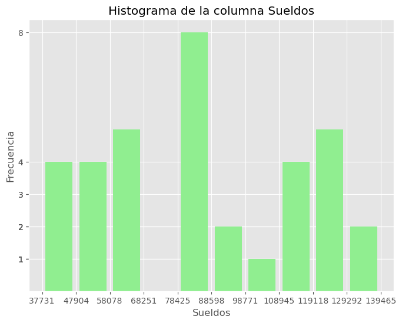

```python
df1['Sueldo'].plot(kind='hist', figsize=(8,6), xticks=intervalos, yticks=frecuencia, rwidth=0.8, color="lightgreen")

plt.title('Histograma de la columna Sueldos')
plt.ylabel('Frecuencia')
plt.xlabel('Sueldos')

plt.show()
```

En el gráfico se puede apreciar que la mayor frecuencia se da en los sueldos de entre 78.425 y 88.598; la menor frecuencia se da en los sueldos de entre 98.771 y 108.945; mientras que no existen sueldos de entre 68.251 y 78.425.

### Gráfico de cajas - Análisis de la columna "Sueldo"

El gráfico de cajas es un método para representar graficamente un conjunto de datos numéricos a traves de sus cuartiles. De esta manera, el gráfico muestra a simple vista la mediana y los cuartiles de los datos.

Para graficarlo utilizamos también el método **`plot()`** con el parámetro **`kind='box'`** para especificar el tipo de gráfico.

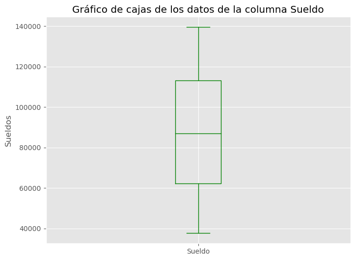

```python
df1['Sueldo'].plot(kind='box', figsize=(8,6), color='green')

plt.title('Gráfico de cajas de los datos de la columna Sueldo')
plt.ylabel('Sueldos')

plt.show()
```

Se puede observar que:

- El salario mínimo está un poco por debajo de los 40000.
- El salario máximo está bastante cerca de los 140000.
- La media de salarios es de entre 85000 y 90000; el 50% de los salarios está por debajo de los ~90000.
- El 25% de los salarios está entre los ~40000 y los ~62000.
- El 75% de los salarios está por debajo de los ~110000; y el 25% de los salarios está por encima de los ~110000.
- No hay valores aberrantes.

### Gráfico de barras - Análisis de la columna "Años de experiencia"

Un gráfico de barras se utiliza para representar una distribución de frecuencias de datos discretos o categóricos, como los que tenemos en la columna `Años de experiencia`. Para realizar un gráfico de barras se utiliza el método **`bar()`** de `Matplotlib`, aunque también se puede utilizar el método **`plot()`** con el parámetro **`kind='bar'`**. Pero antes,se debe determinar la frecuencia de los valores de la columna `Años de experiencia` y para ello se utiliza el método **`value_counts()`** de `Pandas`.

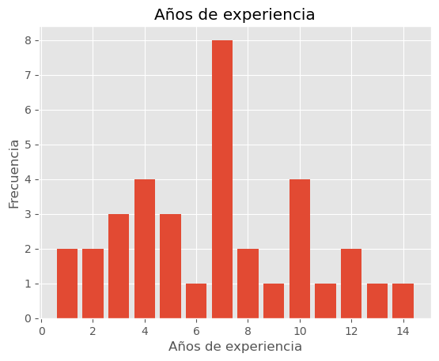

```python
# Calcular la frecuencia de los años de experiencia
frecuencia = df1['Años de experiencia'].value_counts()

# Crear el gráfico de barras
plt.bar(frecuencia.index, frecuencia)

plt.title('Años de experiencia')
plt.xlabel('Años de experiencia')
plt.ylabel('Frecuencia')

# Mostrar el gráfico
plt.show()
```

Se puede observar que los años de experiencia van desde 1 año hasta los 14 años, y que la mayor frecuencia corresponde para los 7 años de experiencia. También se puede ver que la distribución de los datos es practicamanete simétrica. Esto se puede corroborar calculando la media, la mediana y la moda. Para ello se utilizan los métodos **`mean()`** y **`median()`** de `Numpy`, y el método **`mode()`** de la librería `Scipy`.

```python
from scipy import stats #importo el módulo stats de la librería scipy para poder calcular la moda

media = np.mean(df1['Años de experiencia']) #cálculo de la media
mediana = np.median(df1['Años de experiencia']) #cálculo de la mediana
moda = stats.mode(df1['Años de experiencia'], keepdims='True') #cálculo de la moda

print('La media es: ' + str(media))
print('La mediana es: ' + str(mediana))
print('La moda es: ' + str(moda))
```

```
La media es: 6.714285714285714
La mediana es: 7.0
La moda es: ModeResult(mode=array([7]), count=array([8]))
```

La moda y la mediana son iguales a 7; mientras que la media es 6.7, lo que puede significar que hay algunos valores más bajos que arrastran la media hacia abajo. Sin embargo, la diferencia entre la media y la mediana no es muy grande, lo que sugiere que no hay una cantidad significativa de valores atípicos en la distribución.

### Diagrama de dispersión - Análisis de los datos de ambas columnas

Los diagramas de dispersión muestran de manera gráfica la relación que hay entre dos variables cuantitativas. En este caso, se utiliza para observar si hay una relación lineal entre los años de experiencia y el sueldo percibido.

Para realizar el gráfico de dispersión se utiliza el método **`scatter()`** de `Matplotlib`, y para graficar la línea de relación se utiliza el método **`polyfit()`** de `Numpy`.

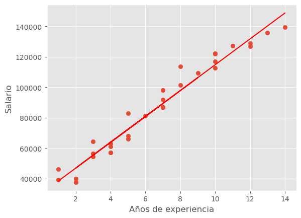

```python
x = df1["Años de experiencia"] # Eje x
y = df1["Sueldo"] # Eje y


pend, inter = np.polyfit(x, y, 1) #Ajusto la línea de relación

plt.scatter(x, y) # Diagrama de dispersión
plt.plot(x, pend*x + inter, color='r') # Grafico la línea de relación en el diagrama
plt.xlabel("Años de experiencia")
plt.ylabel("Salario")
plt.show()
```

A simple vista se puede observar que hay una relación lineal directa entre las dos variables. Esto se puede verificar calculando la covarianza y el coeficiente de correlación.

La *covarianza* es una medida descriptiva que permite determinar el tipo de relación lineal entre dos variables. Y se calcula utilizando la función **`cov()`** de `Numpy`.

```python
covarianza = np.cov(x,y)
cov = round(covarianza[0,1], 2)
print('La covarianza es: ' + str(cov))
```

```
La covarianza es: 101993.47
```

El valor positivo de la covarianza indica que la relación lineal entre los años de experiencia y el sueldo es directa, es decir, cuando aumentan los años de experiencia también lo hacen los sueldos.

```python
coeficiente_corr= np.corrcoef(x,y)
coef_corr = round(coeficiente_corr[0,1], 2)
print('El coeficiente de correlación es: ' + str(coef_corr))
```

```
El coeficiente de correlación es: 0.98
```

El valor del coeficiente de correlación cercano a 1 indica una correlación fuerte, es decir, que la relación lineal es directa y fuerte.